# ExtraaLearn Project

# Visualizing the Decision Tree

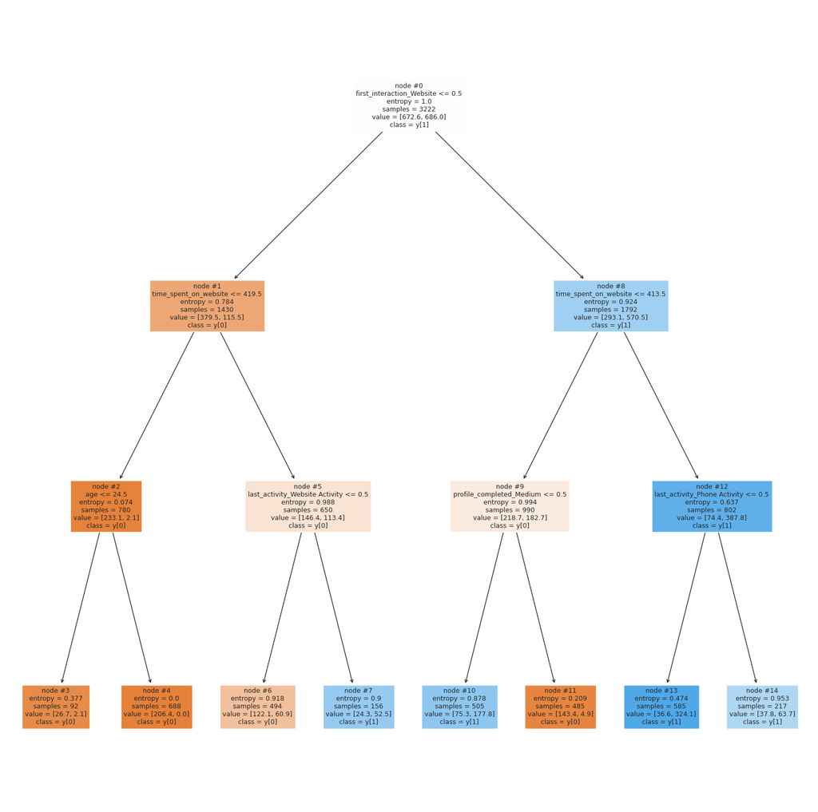

```python
# Decision Tree feature visualization
features = list(X.columns)

plt.figure(figsize = (20, 20))
tree.plot_tree(d_tree_tuned, feature_names = features, filled = True, fontsize = 9, node_ids = True, class_names = True)
plt.show()
```

```python
# Importance of features in the tree building
print (pd.DataFrame(d_tree_tuned.feature_importances_, columns = ["Imp"], index = X_train.columns).sort_values(by = 'Imp', ascending = False))
```

```
                                     Imp
time_spent_on_website           0.370945
first_interaction_Website       0.292292
profile_completed_Medium        0.247129
last_activity_Phone Activity    0.045324
last_activity_Website Activity  0.033351
age                             0.010958
website_visits                  0.000000
page_views_per_visit            0.000000
current_occupation_Student      0.000000
current_occupation_Unemployed   0.000000
profile_completed_Low           0.000000
print_media_type1_Yes           0.000000
print_media_type2_Yes           0.000000
digital_media_Yes               0.000000
educational_channels_Yes        0.000000
referral_Yes                    0.000000
```

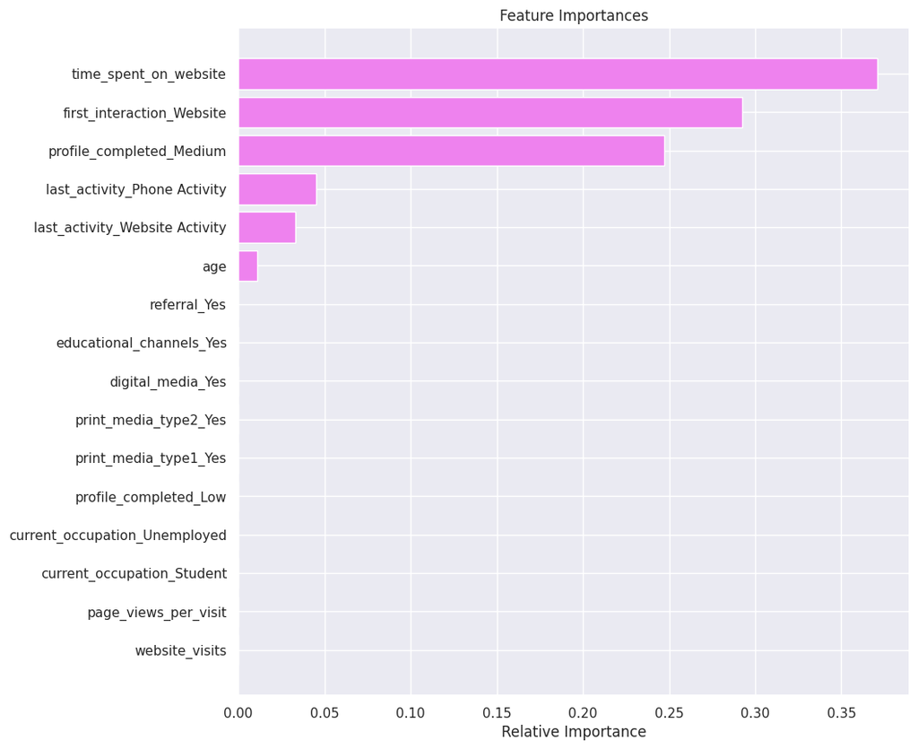

```python
# Plotting the feature importance
importances = d_tree_tuned.feature_importances_
indices = np.argsort(importances)

plt.figure(figsize = (10, 10))
plt.title('Feature Importances')
plt.barh(range(len(indices)), importances[indices], color = 'violet', align = 'center')
plt.yticks(range(len(indices)), [features[i] for i in indices])
plt.xlabel('Relative Importance')
plt.show()
```

## Building a Random Forest model

```python
# Fitting the random forest classifier on the training data
rf_estimator = RandomForestClassifier(random_state=1)  # Create an instance of RandomForestClassifier

rf_estimator.fit(X_train, y_train)  # Fit the classifier on the training data
```

```
RandomForestClassifier(random_state=1)
```

```
              precision    recall  f1-score   support

           0       1.00      1.00      1.00      2242
           1       1.00      1.00      1.00       980

    accuracy                           1.00      3222
   macro avg       1.00      1.00      1.00      3222
weighted avg       1.00      1.00      1.00      3222
```

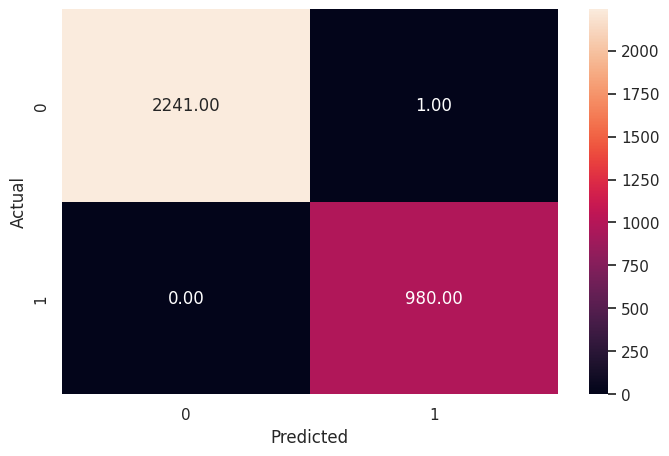

```python
# Checking performance on the training data
y_pred_train3 = rf_estimator.predict(X_train)  # Make predictions on the training data

metrics_score(y_train, y_pred_train3)  # Evaluate the predictions
```

```
              precision    recall  f1-score   support

           0       0.90      0.92      0.91       986
           1       0.79      0.76      0.77       395

    accuracy                           0.87      1381
   macro avg       0.85      0.84      0.84      1381
weighted avg       0.87      0.87      0.87      1381
```

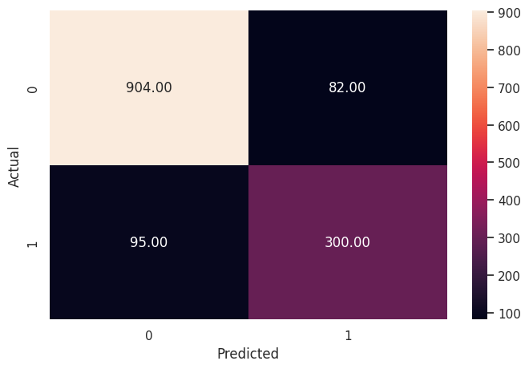

```python
# Checking performance on the testing data
y_pred_test3 = rf_estimator.predict(X_test)  # Make predictions on the testing data

metrics_score(y_test, y_pred_test3)  # Evaluate the predictions
```

## Do we need to prune the tree?

```python
from sklearn.metrics import recall_score
# Choose the type of classifier
rf_estimator_tuned = RandomForestClassifier(criterion="entropy", random_state=7)

# Grid of parameters to choose from
parameters = {
    "n_estimators": [110, 120],
    "max_depth": [6, 7],
    "min_samples_leaf": [20, 25],
    "max_features": [0.8, 0.9],
    "max_samples": [0.9, 1],
    "class_weight": ["balanced", {0: 0.3, 1: 0.7}]
}

# Type of scoring used to compare parameter combinations - recall score for class 1
scorer = metrics.make_scorer(recall_score, pos_label=1)

# Run the grid search on the training data using scorer=scorer and cv=5
grid_obj = GridSearchCV(rf_estimator_tuned, parameters, scoring=scorer, cv=5)
grid_obj.fit(X_train, y_train)

# Save the best estimator to variable rf_estimator_tuned
rf_estimator_tuned = grid_obj.best_estimator_
```

```python
# Fitting the best algorithm to the training data
rf_estimator_tuned.fit(X_train, y_train)
```

```
RandomForestClassifier(class_weight='balanced', criterion='entropy',
                       max_depth=6, max_features=0.8, max_samples=0.9,
                       min_samples_leaf=25, n_estimators=120, random_state=7)
```

```
              precision    recall  f1-score   support

           0       0.94      0.84      0.88      2242
           1       0.70      0.87      0.77       980

    accuracy                           0.85      3222
   macro avg       0.82      0.85      0.83      3222
weighted avg       0.86      0.85      0.85      3222
```

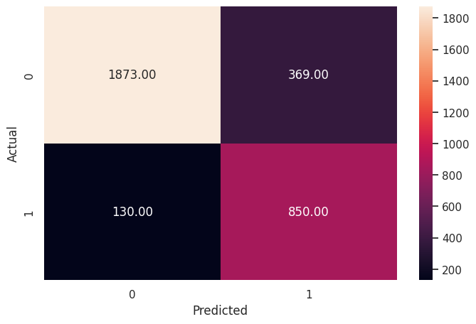

```python
# Checking performance on the training data
y_pred_train4 = rf_estimator_tuned.predict(X_train)  # Make predictions on the training data

metrics_score(y_train, y_pred_train4)  # Evaluate the predictions
```

```
              precision    recall  f1-score   support

           0       0.94      0.82      0.87       986
           1       0.66      0.86      0.74       395

    accuracy                           0.83      1381
   macro avg       0.80      0.84      0.81      1381
weighted avg       0.86      0.83      0.84      1381
```

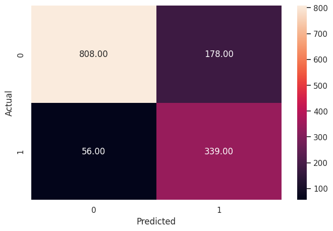

```python
# Checking performance on the test data
y_pred_test4 = rf_estimator_tuned.predict(X_test)  # Make predictions on the test data

metrics_score(y_test, y_pred_test4)  # Evaluate the predictions
```

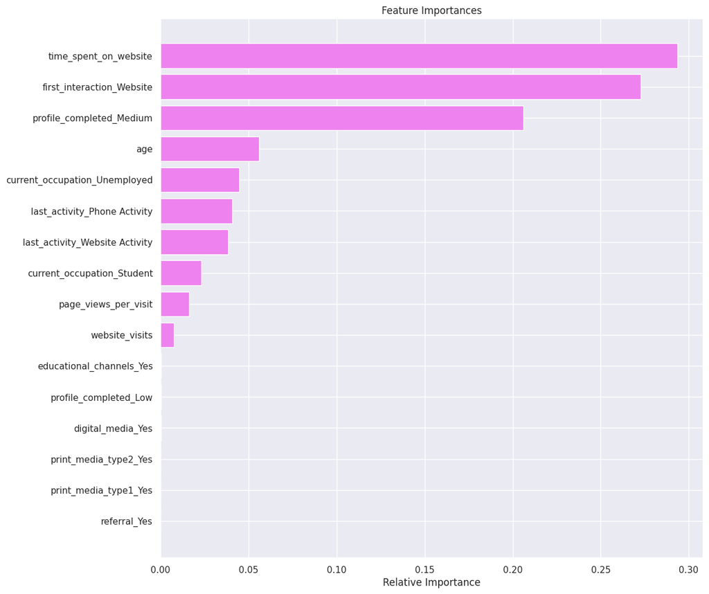

```python
#checking the feature importance of the model.
importances = rf_estimator_tuned.feature_importances_
indices = np.argsort(importances)
feature_names = list(X.columns)

plt.figure(figsize = (12, 12))
plt.title('Feature Importances')
plt.barh(range(len(indices)), importances[indices], color = 'violet', align = 'center')
plt.yticks(range(len(indices)), [feature_names[i] for i in indices])
plt.xlabel('Relative Importance')
plt.show()
```

## Actionable Insights and Recommendations

**1. Demographic Analysis:**

- Analyze the distribution of customers by age to identify any age groups that are more likely to convert.
- Investigate the current occupation of customers to understand the occupation profiles of potential converters.

**2. User Engagement:**

- Explore the first interaction and last activity timestamps to understand the customer journey and identify key touchpoints.
- Analyze website visits, time spent on the website, and page views per visit to assess user engagement levels.

**3. Marketing Channels:**

- Evaluate the effectiveness of different marketing channels such as print media, digital media, educational channels, and referrals in acquiring customers.
- Identify the most successful marketing channels for customer acquisition and prioritize investment in those channels.
1. Profile Completion:
- Investigate the impact of profile completion on conversion rates to encourage users to complete their profiles.
- Implement strategies to incentivize users to complete their profiles, such as offering discounts or exclusive access to features.

**5. Conversion Prediction:**